# Fitting and Predicting with cosTapered

Andrew O. Finley, Lu Zhang, Arne Nothdurft, and Sudipto Banerjee

2026-05-17

## Overview

`cosTapered` fits a Bayesian change-of-support model for settings where a response is observed over polygons, covariates are available on a fine raster support, and predictions are needed for raster cells or other polygons. The model follows Zhang, Finley, Nothdurft, and Banerjee (2024) and uses a tapered exponential covariance for residual spatial variation.

The main workflow is:

1. Prepare observed-support weights and covariates with `cos_prepare()`.
2. Set priors with `cos_default_priors()`.
3. Fit covariance parameters with `cos_fit()`.
4. Recover fitted observed-support latent quantities with `cos_recover_B()`.
5. Predict fine-support or areal-support latent or observed responses with `cos_predict_fine()` and `cos_predict_areal()`.
6. Check fitted and held-out prediction behavior with generic `summary()`, `plot()`, and `cos_cv_observed()`.

The examples below use the small dataset installed with the package. The included response values are simulated, so the example contains known truth for checking parameter recovery and fitted values. The bundled data are generated by `dev/make_example_data.R`, which calls `cos_simulate_data()`.

## Model

Let $A_i$, $i = 1,\ldots,n_a$, denote raster cells with centroids $s_i$. Let $B_l$, $l = 1,\ldots,n_b$, denote observed-support polygons, and let $U_k$, $k = 1,\ldots,n_u$, denote areal prediction polygons.

At the fine support, the latent response is

$$\eta(A_i) = x(A_i)^\top \beta + \omega(A_i),$$

where $x(A_i)$ is the user-prepared covariate vector, $\beta$ is a vector of regression coefficients, and $\omega(A_i)$ is a spatial random effect. The observed fine-support response is

$$y(A_i) = \eta(A_i) + \epsilon(A_i),$$

where $\epsilon(A_i)$ is independent fine-support noise.

The spatial covariance is an exponential covariance multiplied by a compact taper:

$$\operatorname{cor}\{\omega(A_i), \omega(A_j)\}
= \exp\{-\phi d(s_i,s_j)\} T_\gamma\{d(s_i,s_j)\}.$$

Here $d(\cdot,\cdot)$ is Euclidean distance in the projected CRS, $\phi > 0$ controls exponential correlation decay, and $\gamma > 0$ is a fixed taper distance chosen by the user. The package reports the exponential effective spatial range as the distance where the exponential correlation drops to 0.05:

$$\exp(-\phi r) = 0.05
\quad \Rightarrow \quad
r = -\log(0.05) / \phi \approx 3 / \phi.$$

The taper distance $\gamma$ is different from this effective range. Correlation from the exponential component decays continuously, while the taper forces covariance to exactly zero at distance $\gamma$. In practice, choose $\gamma$ large enough to cover the largest residual spatial range that matters for the prediction task, while remembering that larger $\gamma$ increases computation.

Observed polygons are linked to the fine support through area weights

$$h_{li} = |B_l \cap A_i| / |B_l|.$$

Let $H_{BA}$ be the matrix of these weights. Then

$$\eta_B = H_{BA}X\beta + H_{BA}\omega_A.$$

Define $X_B = H_{BA}X$, $\omega_B = H_{BA}\omega_A$, and $D_h = H_{BA}H_{BA}^\top$. The observed-support model is

$$y_B \mid \beta, \omega_B, \tau^2
\sim N(\eta_B, \tau^2 D_h),
\qquad
\eta_B = X_B\beta + \omega_B,$$

with

$$\omega_B \mid \sigma^2, \phi, \gamma
\sim N(0, \sigma^2 C_B^{tap}),
\qquad
C_B^{tap} = H_{BA} C_{\phi,\gamma}^{tap} H_{BA}^\top.$$

`cosTapered` computes the entries of $C_B^{tap}$ directly from local fine-cell pairs, rather than forming the full fine-support covariance matrix.

The sampler places the prior on

$$\tau_B^2 = \tau^2 \bar d_h,
\qquad
\bar d_h = n_b^{-1}\sum_l D_h(l,l),$$

which is the average observed-support nugget variance contribution. Recovery and prediction convert back to $\tau^2 = \tau_B^2 / \bar d_h$. Prediction functions default to the latent target $\eta$. When `target = "observed"`, they add independent nugget draws at the requested support.

## Choosing gamma and phi bounds

Start by thinking in distance units of the projected CRS.

- Use the raster cell size to rule out implausibly short residual ranges. A range shorter than a few cells usually means the residual process is almost unresolved by the raster.
- Use scientific knowledge and exploratory variograms or residual maps to pick plausible residual effective ranges.
- Convert plausible effective range bounds to `phi` bounds with `phi_lower = 3 / r_max` and `phi_upper = 3 / r_min`.
- Choose `gamma` at least as large as the largest effective range you want the model to represent. Smaller `gamma` values are faster but more strongly localize residual dependence.
- Fit a few plausible `gamma` values when the prediction target is sensitive to short-range behavior.

In this example, the true simulated effective range is 250 map units, and the example uses `gamma = 350`. A prior range of 80 to 600 map units corresponds to:

```r
range_min <- 80
range_max <- 600
c(phi_lower = 3 / range_max, phi_upper = 3 / range_min)
```

```
#> phi_lower phi_upper
#>    0.0050    0.0375
```

## Read and plot the example data

```r
library(sf)
library(raster)
library(ggplot2)
library(cosTapered)
```

```r
chm <- raster(system.file("extdata", "example_chm.tif", package = "cosTapered"))
names(chm) <- "chm"

B_sf <- st_read(system.file("extdata", "example_B.gpkg",
                            package = "cosTapered"), quiet = TRUE)
U_sf <- st_read(system.file("extdata", "example_U.gpkg",
                            package = "cosTapered"), quiet = TRUE)
forest_sf <- st_read(system.file("extdata", "example_forest.gpkg",
                                 package = "cosTapered"), quiet = TRUE)
truth <- readRDS(system.file("extdata", "example_truth.rds",
                             package = "cosTapered"))

truth[c("beta_true", "tau_B_sq_true", "sigma_sq_true",
        "eff_range_true", "phi_true", "gamma", "n_B", "n_U")]
```

```
#> $beta_true
#> intercept       chm
#>     45.00      1.25
#>
#> $tau_B_sq_true
#> [1] 8
#>
#> $sigma_sq_true
#> [1] 35
#>
#> $eff_range_true
#> [1] 250
#>
#> $phi_true
#> [1] 0.012
#>
#> $gamma
#> [1] 350
#>
#> $n_B
#> [1] 36
#>
#> $n_U
#> [1] 49
```

The package does not add an intercept or scale covariates automatically. Users should construct `X_rast` exactly as they want the model to see it.

```r
intercept <- chm
intercept[] <- ifelse(is.na(getValues(chm)), NA_real_, 1)
names(intercept) <- "intercept"

X_rast <- stack(intercept, chm)
names(X_rast) <- c("intercept", "chm")
```

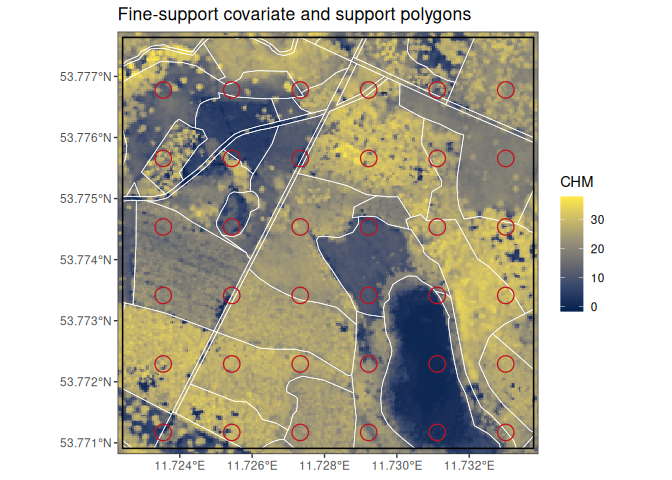

```r
chm_df <- as.data.frame(chm, xy = TRUE, na.rm = TRUE)
names(chm_df) <- c("x", "y", "chm")

ggplot() +
  geom_tile(data = chm_df, aes(x = x, y = y, fill = chm),
            width = xres(chm), height = yres(chm)) +
  geom_sf(data = U_sf, fill = NA, color = "white", linewidth = 0.25) +
  geom_sf(data = forest_sf, fill = NA, color = "black", linewidth = 0.55) +
  geom_sf(data = B_sf, fill = NA, color = "#c1121f", linewidth = 0.45) +
  scale_fill_viridis_c(option = "cividis") +
  coord_sf(expand = FALSE) +
  labs(title = "Fine-support covariate and support polygons",
       fill = "CHM", x = NULL, y = NULL) +
  theme_bw()
```

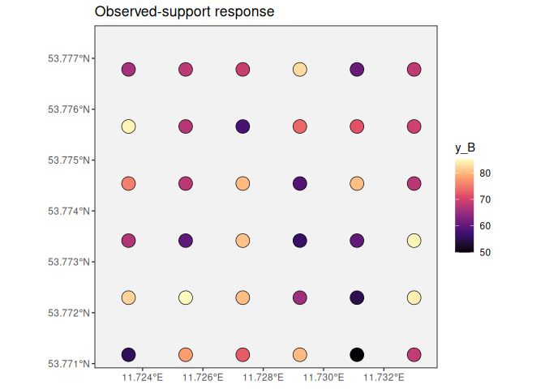

```r
ggplot() +
  geom_sf(data = forest_sf, fill = "grey95", color = "grey60",
          linewidth = 0.35) +
  geom_sf(data = B_sf, aes(fill = y_B), color = "black", linewidth = 0.25) +
  scale_fill_viridis_c(option = "magma") +
  coord_sf(expand = FALSE) +
  labs(title = "Observed-support response", fill = "y_B",
       x = NULL, y = NULL) +
  theme_bw()
```

## Prepare supports

`cos_prepare()` computes raster-polygon support weights, observed-support covariates, the nugget matrix $D_h$, and the tapered covariance pair pattern for the chosen `gamma`.

```r
prep <- cos_prepare(
  X_rast = X_rast,
  B_sf = B_sf,
  response_col = "y_B",
  gamma = truth$gamma,
  taper_code = truth$taper_code,
  n_threads = 1,
  verbose = FALSE
)

summary(prep)
```

Rows of $H_{BA}$ should usually be close to one. Values below one indicate that some part of an observed polygon had missing covariates or fell outside the raster support.

## Set priors

The current package supports a proper normal prior for $\beta$, inverse-gamma priors for `tau_B_sq` and `sigma_sq`, and a bounded uniform prior for `phi`. Choose beta priors on the scale of the covariates as supplied in `X_rast`.

```r
priors <- cos_default_priors(
  prep = prep,
  beta_mu = c(intercept = 40, chm = 1),
  beta_sd = c(intercept = 20, chm = 2),
  tau_B_shape = 2,
  tau_B_scale = truth$tau_B_sq_true,
  sigma_shape = 2,
  sigma_scale = truth$sigma_sq_true,
  phi_lower = 3 / 600,
  phi_upper = 3 / 80
)

priors
```

## Fit the model

`cos_fit()` samples the collapsed posterior for covariance parameters. The examples below use short MCMC settings so the code is easy to run. Use longer chains for real inference.

```r
fit <- cos_fit(
  prep = prep,
  priors = priors,
  n_chains = 3,
  starting = data.frame(
    tau_B_sq = truth$tau_B_sq_true,
    sigma_sq = truth$sigma_sq_true,
    phi = truth$phi_true
  ),
  tuning = c(log_tau_B_sq = 0.25, log_sigma_sq = 0.25, z_phi = 0.25),
  n_batch = 50,
  batch_length = 10,
  seed = 1,
  verbose = TRUE
)

summary(fit, burn_in = 25)
plot(fit, burn_in = 25)
```

For multiple chains, use deliberately dispersed starting values:

```r
fit <- cos_fit(
  prep = prep,
  priors = priors,
  n_chains = 3,
  starting = data.frame(
    tau_B_sq = truth$tau_B_sq_true * c(0.5, 1, 2),
    sigma_sq = truth$sigma_sq_true * c(0.5, 1, 2),
    phi = truth$phi_true * c(0.75, 1, 1.25)
  ),
  #tuning = c(log_tau_B_sq = 0.25, log_sigma_sq = 0.25, z_phi = 0.25),
  n_batch = 100,
  batch_length = 25,
  seed = 1,
  verbose = TRUE
)

summary(fit, burn_in = 50)
plot(fit, burn_in = 50)
```

Trace plots should move across stable regions after burn-in, and `phi` should not be pinned against the prior bounds. If `phi` piles up near a boundary, revisit the effective range bounds or the taper distance.

Because this dataset is simulated, we can compare posterior samples with the known values stored in `truth`.

```r
theta <- fit$theta_samples
theta <- theta[theta$iter >= 50, ]

theta_long <- reshape(
  theta[, c("chain", "iter", "tau_B_sq", "sigma_sq", "phi", "eff_range")],
  varying = c("tau_B_sq", "sigma_sq", "phi", "eff_range"),
  v.names = "value",
  timevar = "parameter",
  times = c("tau_B_sq", "sigma_sq", "phi", "eff_range"),
  direction = "long"
)

truth_df <- data.frame(
  parameter = c("tau_B_sq", "sigma_sq", "phi", "eff_range"),
  truth = c(truth$tau_B_sq_true, truth$sigma_sq_true,
            truth$phi_true, truth$eff_range_true)
)

ggplot(theta_long, aes(x = value)) +
  geom_density(fill = "grey80", color = "grey25", linewidth = 0.35) +
  geom_vline(data = truth_df, aes(xintercept = truth),
             color = "#c1121f", linewidth = 0.7) +
  facet_wrap(~ parameter, scales = "free", ncol = 2) +
  labs(title = "Posterior distributions and known simulation values",
       x = NULL, y = NULL) +
  theme_bw()
```

## Recover fitted observed-support quantities

`cos_recover_B()` samples $\beta$, $\omega_B$, and the fitted latent observed-support means $\eta_B = X_B\beta + \omega_B$ conditional on retained covariance-parameter samples.

```r
rec_B <- cos_recover_B(
  fit = fit,
  burn_in = 50,
  n_samples = 100,
  seed = 1,
  verbose = FALSE
)

rec_sum <- summary(rec_B, include_eta_B = TRUE)
rec_sum
```

The example data include `eta_B_true`, so we can check fitted values.

```r
B_plot <- B_sf
B_plot$eta_B_mean <- rec_sum$eta_B_summary$mean[
  match(B_plot$B_id, rec_sum$eta_B_summary$B_id)
]
B_plot$eta_B_error <- B_plot$eta_B_mean - B_plot$eta_B_true

ggplot(B_plot, aes(x = eta_B_true, y = eta_B_mean)) +
  geom_abline(slope = 1, intercept = 0, color = "grey45", linewidth = 0.4) +
  geom_point(size = 2) +
  coord_equal() +
  labs(title = "Recovered observed-support latent means",
       x = "Simulated eta_B truth",
       y = "Posterior mean") +
  theme_bw()

ggplot() +
  geom_sf(data = forest_sf, fill = "grey95", color = "grey60",
          linewidth = 0.35) +
  geom_sf(data = B_plot, aes(fill = eta_B_error),
          color = "black", linewidth = 0.25) +
  scale_fill_gradient2(low = "#2b6cb0", mid = "white", high = "#c1121f") +
  coord_sf(expand = FALSE) +
  labs(title = "Fitted eta_B posterior mean minus truth",
       fill = "error", x = NULL, y = NULL) +
  theme_bw()
```

## Predict the fine-support surface

With no `pred_coords` or `X_pred`, `cos_predict_fine()` predicts on the fine cells retained by `cos_prepare()`.

```r
pred_fine <- cos_predict_fine(
  fit = fit,
  rec_B = rec_B,
  method = "mean",
  verbose = FALSE
)

summary(pred_fine)
```

```r
fine_df <- pred_fine$summary[, c("x", "y", "eta_mean", "eta_sd")]

ggplot() +
  geom_tile(data = fine_df, aes(x = x, y = y, fill = eta_mean),
            width = xres(chm), height = yres(chm)) +
  geom_sf(data = B_sf, fill = NA, color = "black", linewidth = 0.25) +
  geom_sf(data = forest_sf, fill = NA, color = "white", linewidth = 0.35) +
  scale_fill_viridis_c(option = "magma") +
  coord_sf(expand = FALSE) +
  labs(title = "Fine-support posterior mean",
       fill = "eta mean", x = NULL, y = NULL) +
  theme_bw()

ggplot() +
  geom_tile(data = fine_df, aes(x = x, y = y, fill = eta_sd),
            width = xres(chm), height = yres(chm)) +
  geom_sf(data = B_sf, fill = NA, color = "black", linewidth = 0.25) +
  geom_sf(data = forest_sf, fill = NA, color = "white", linewidth = 0.35) +
  scale_fill_viridis_c(option = "cividis") +
  coord_sf(expand = FALSE) +
  labs(title = "Fine-support posterior SD",
       fill = "eta SD", x = NULL, y = NULL) +
  theme_bw()
```

Use `method = "sample"` only for small fine grids because it forms dense fine-support covariance matrices. For large rasters, `method = "mean"` is the usual mapping option.

## Predict areal supports

`cos_make_areal_blocks()` computes area weights and covariate averages for prediction polygons. Inspect its summary before prediction.

```r
U_blocks <- cos_make_areal_blocks(
  U_sf = U_sf,
  X_rast = X_rast,
  id_col = "U_id",
  verbose = FALSE
)

summary(U_blocks)
```

```r
pred_U <- cos_predict_areal(
  fit = fit,
  rec_B = rec_B,
  U_blocks = U_blocks,
  method = "mean",
  verbose = TRUE
)

summary(pred_U)
```

```r
U_plot <- pred_U$U_blocks$U_sf
U_plot$eta_mean <- pred_U$summary$eta_mean[
  match(U_plot$U_id, pred_U$summary$U_id)
]
U_plot$eta_sd <- pred_U$summary$eta_sd[
  match(U_plot$U_id, pred_U$summary$U_id)
]

ggplot() +
  geom_sf(data = forest_sf, fill = "grey95", color = "grey60",
          linewidth = 0.35) +
  geom_sf(data = U_plot, aes(fill = eta_mean),
          color = "white", linewidth = 0.25) +
  geom_sf(data = B_sf, fill = NA, color = "black", linewidth = 0.2) +
  scale_fill_viridis_c(option = "magma") +
  coord_sf(expand = FALSE) +
  labs(title = "Areal posterior mean",
       fill = "eta mean", x = NULL, y = NULL) +
  theme_bw()

ggplot() +
  geom_sf(data = forest_sf, fill = "grey95", color = "grey60",
          linewidth = 0.35) +
  geom_sf(data = U_plot, aes(fill = eta_sd),
          color = "white", linewidth = 0.25) +
  geom_sf(data = B_sf, fill = NA, color = "black", linewidth = 0.2) +
  scale_fill_viridis_c(option = "cividis") +
  coord_sf(expand = FALSE) +
  labs(title = "Areal posterior SD",
       fill = "eta SD", x = NULL, y = NULL) +
  theme_bw()
```

`cos_predict_areal()` defaults to `target = "latent"` and reports areal latent means. Use `target = "observed"` when the target includes the support-level nugget term. The function does not compute totals; multiply by the chosen area units outside the package if totals are needed.

## K-fold predictive validation

`cos_cv_observed()` refits the model across folds and predicts held-out observed-support polygons. By default it scores the observed response `y_B`. For simulated examples with known latent truth, it can score both latent and observed targets from the same fold refits.

```r
set.seed(1)
fold_id <- sample(rep(seq_len(10), length.out = nrow(B_sf)))

cv <- cos_cv_observed(
  fit = fit,
  X_rast = X_rast,
  B_sf = B_sf,
  target = c("latent", "observed"),
  latent_col = "eta_B_true",
  k = 10,
  fold_id = fold_id,
  fit_args = list(n_batch = 50, batch_length = 8),
  recover_args = list(burn_in = 100, n_samples = 60),
  seed = 1,
  verbose = FALSE
)

summary(cv)
cv$fold_summary
```

```r
ggplot(cv$predictions, aes(x = truth, y = pred_mean)) +
  geom_abline(slope = 1, intercept = 0, color = "grey45", linewidth = 0.4) +
  geom_errorbar(aes(ymin = q025, ymax = q975),
                width = 0, alpha = 0.55) +
  geom_point(aes(color = covered_95), size = 2) +
  facet_wrap(~ target, scales = "free") +
  labs(title = "Held-out observed-support predictions",
       x = "Truth", y = "Posterior predictive mean",
       color = "Covered") +
  theme_bw()
```

For simulation-based validation studies, see the scripts in `dev/`, including the repeated range/target cross-validation study. Those scripts repeatedly draw new responses from a fixed design, refit the model, and summarize predictive scores and interval coverage.

## Non-spatial baseline

A non-spatial COS baseline uses the same support weights and regression model but fixes $\omega(\cdot)=0$. This is useful for checking whether the spatial random effect improves prediction.

```r
prep_ns <- cos_prepare(
  X_rast = X_rast,
  B_sf = B_sf,
  response_col = "y_B",
  spatial = FALSE,
  verbose = FALSE
)

priors_ns <- cos_default_priors(
  prep = prep_ns,
  beta_mu = c(intercept = 40, chm = 1),
  beta_sd = c(intercept = 20, chm = 2),
  tau_B_shape = 2,
  tau_B_scale = truth$tau_B_sq_true
)

fit_ns <- cos_fit(
  prep = prep_ns,
  priors = priors_ns,
  starting = c(tau_B_sq = truth$tau_B_sq_true),
  tuning = c(log_tau_B_sq = 0.25),
  n_batch = 50,
  batch_length = 8,
  seed = 1,
  verbose = FALSE
)

summary(fit_ns, burn_in = 100)
plot(fit_ns, burn_in = 100)
```

Use the same `fold_id` in `cos_cv_observed()` for spatial and non-spatial fits when comparing held-out predictive scores.

The validation vignette gives more detail on observed-support cross validation, stand-support validation, and simulation settings that isolate when the spatial random effect should improve prediction.

## Reference

Zhang, L., Finley, A. O., Nothdurft, A., and Banerjee, S. (2024). Bayesian modeling of incompatible spatial data: A case study involving Post-Adrian storm forest damage assessment. *International Journal of Applied Earth Observation and Geoinformation*, 135, 104224. doi:10.1016/j.jag.2024.104224.